# individual1

Adam Ford

11/4/2020

## Import

```r
library(lubridate)
```

```r
library(ggplot2)
library(dplyr)
library(tidyverse)
library(maps)
accident <- read.csv("https://raw.githubusercontent.com/xdaiISU/ds202materials/master/hwlabs/fars2017/accident.csv", stringsAsFactors = FALSE)
person <- read.csv("https://raw.githubusercontent.com/xdaiISU/ds202materials/master/hwlabs/fars2017/person.csv", stringsAsFactors = FALSE)
```

## 5.

Join the accident and person table (work out which variable(s) to use)

```r
joined <- inner_join(person, accident, by="ST_CASE")
```

The given documentation describes that ST_CASE is the shared variable for merging between accident and person.

## 6.

Tally the number of accidents by day of the week (DAY_WEEK), hour of the day (HOUR) and gender (SEX). Visualize the results.

```r
withAvgSex <- joined %>%
  filter(SEX == 1 || SEX == 2) %>%
  group_by(ST_CASE) %>%
  summarise(avgSex = mean(SEX))
withAvgSex$sexesExplained <- ifelse(withAvgSex$avgSex == 1, 'Men Only', ifelse(withAvgSex$avgSex == 2, 'Women Only', 'Men and Women'))

accident <- withAvgSex %>%
  select(ST_CASE, sexesExplained) %>%
  inner_join( accident, by='ST_CASE')

grouped <- accident %>%
  filter(HOUR <= 24) %>%
  filter(DAY_WEEK != 9) %>%
  group_by(sexesExplained, HOUR, DAY_WEEK) %>%
  summarise(numAccidents = n()) %>%
  arrange(desc(numAccidents))
head(grouped, 10)
```

```
## # A tibble: 10 x 4
## # Groups:   sexesExplained, HOUR [7]
##    sexesExplained  HOUR DAY_WEEK numAccidents
##    <chr>          <int>    <int>        <int>
##  1 Men Only           2        1          180
##  2 Men and Women     18        6          173
##  3 Men and Women     18        1          172
##  4 Men and Women     20        7          172
##  5 Men and Women     21        6          172
##  6 Men and Women     23        7          170
##  7 Men and Women     18        7          168
##  8 Men and Women     21        7          163
##  9 Men Only           1        1          163
## 10 Men Only          22        6          163
```

From this table we begin to understand that the weekends have the most accidents, especially later at night.

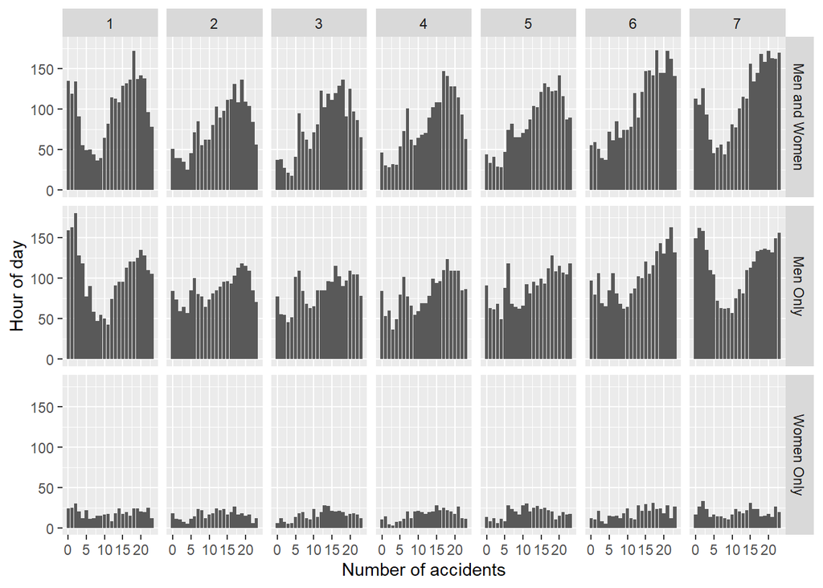

```r
ggplot(grouped,aes(x=HOUR, y=numAccidents)) + geom_bar(stat='identity') + facet_grid(sexesExplained~DAY_WEEK)+xlab("Number of accidents")+ylab("Hour of day")
```

This graph shows several factors off the count of accidents. First off, we see the number of accidents thats participants are only female is significantly smaller than the number of accidents with only men. As expected, the number of accidents involving Men and Women is the most. This graph also shows the trends of the weekends and the night having more accidents.

## 7.

Now plot a choropleth map of the number of deaths on a county level.

```r
deathCounty <- person %>%
  filter(INJ_SEV == 4) %>%
  group_by(STATE, COUNTY) %>%
  summarise(numDeaths = n())
```

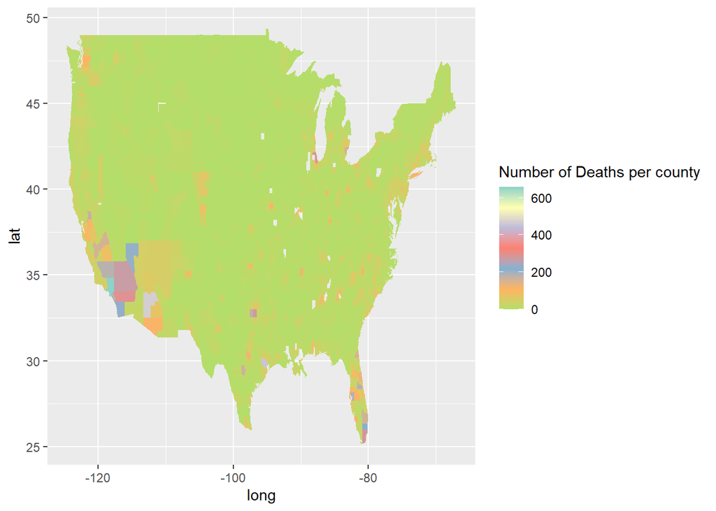

```r
counties <- map_data("county")
countyStateCodes <- readr::read_csv('statesCounties.csv')
countyStateCodes$StateName <- tolower(countyStateCodes$StateName)
countyStateCodes$CountyName <- tolower(countyStateCodes$CountyName)
countyStateCodes$StateCode <- as.numeric(countyStateCodes$StateCode)
countyStateCodes$CountyCode <- as.numeric(countyStateCodes$CountyCode)
deathCounty$STATE <- as.numeric(deathCounty$STATE)
deathCounty$COUNTY <- as.numeric(deathCounty$COUNTY)
withNames <- right_join(deathCounty, countyStateCodes, by = c("STATE" = "StateCode", "COUNTY" = "CountyCode"))
withNames$numDeaths <- replace_na(withNames$numDeaths, 0)
 allTogether <- inner_join(withNames, counties, by = c("StateName" = "region", "CountyName" = "subregion"))
 allTogether %>% ggplot(aes(x=long, y=lat))+geom_polygon(aes(group=group, fill=numDeaths))+scale_fill_distiller(name="Number of Deaths per county", palette = "Set3")
```

This map shows two main hotspots of fatal accidents, California and Florida. Other metropolitan areas register as dangerous as well, but not as bad as the mentioned hot spots.

## 8.

Is summer or winter more dangerous? Does this depend on states? Explore and explain.

```r
summer <- c(5,6,7,8)
winter <- c(12, 1, 2, 3)
accident$sumWint <- ifelse(accident$MONTH %in% summer, 'Summer', ifelse(accident$MONTH %in% winter, 'Winter', 'Neither') )
accident %>%
  filter(sumWint == 'Summer' | sumWint == 'Winter') %>%
  group_by(sumWint) %>%
  summarise(numAcc = n()) %>%
  arrange(desc(numAcc)) %>%
  head()
```

```
## # A tibble: 2 x 2
##   sumWint numAcc
##   <chr>    <int>
## 1 Summer   12101
## 2 Winter   10419
```

This shows that in the dataset there are more accidents in the Summer overall.

```r
accident <- countyStateCodes %>%
  select(StateCode, StateName) %>%
  right_join(accident, by = c("StateCode" = "STATE"))
byState <- accident %>%
  filter(sumWint == 'Summer' | sumWint == 'Winter') %>%
  group_by(sumWint, StateName) %>%
  summarise(numAcc = n()) %>%
  arrange(desc(numAcc))
head(byState, 10)
```

```
## # A tibble: 10 x 3
## # Groups:   sumWint [2]
##    sumWint StateName      numAcc
##    <chr>   <chr>           <int>
##  1 Summer  texas          286258
##  2 Winter  texas          272288
##  3 Summer  georgia         78864
##  4 Winter  georgia         74412
##  5 Winter  florida         70350
##  6 Summer  california      67222
##  7 Summer  florida         61908
##  8 Winter  california      61364
##  9 Summer  north carolina  42420
## 10 Winter  north carolina  41612
```

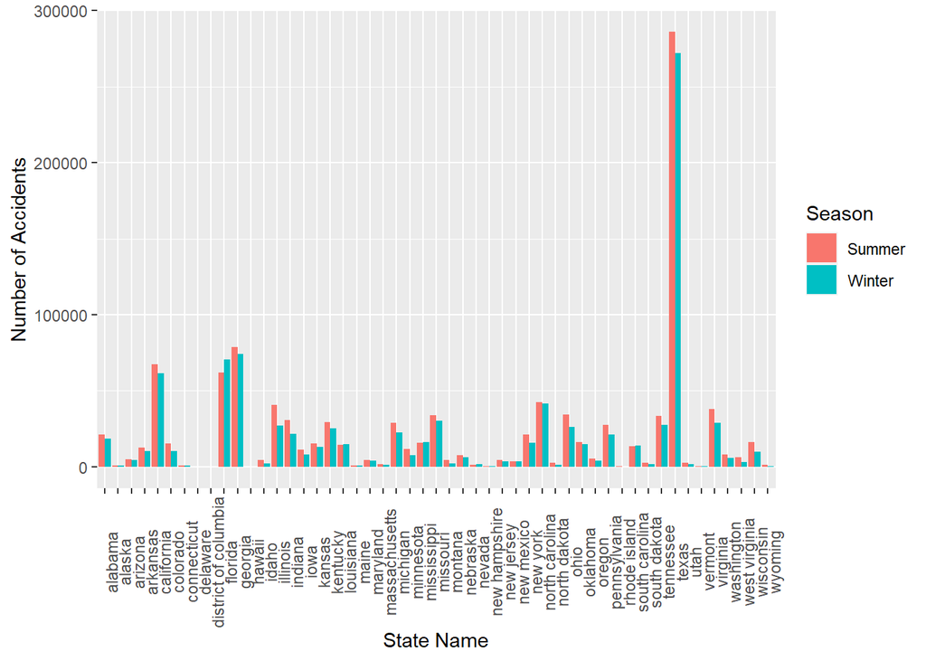

```r
options(scipen=10000)
ggplot(byState, aes(fill=sumWint, x=StateName, y=numAcc))+geom_bar(position='dodge', stat='identity')+theme(axis.text.x = element_text(angle = 90))+labs(fill = "Season")+xlab("State Name")+ylab("Number of Accidents")
```

This graph shows it does vary state by state on if Summer or Winter is more dangerous, however it is more common that Summer has more accidents.